# Metro-Transit-route-change-analysis

Metro Transit Strategic Initiatives

2020-07-13

# Overview

Metro Transit has experienced declining ridership throughout its bus system from 2015 to 2019. A simple probabilistic, hierarchical analysis is presented to understand the differences among route types, and routes based on the amount of service provided.

### Load libs

```r
library(data.table)
library(ggplot2)
library(DT)
knitr::opts_chunk$set(echo = TRUE)

# Metro Transit brand colors
MT_palette <- c('#0053A0','#ED1B2E','#FFD200','#008144','#F68A1E','#ffffff')
```

# Import & Viz the data

The dataset consists of publicly reported annual ridership figures by route from 2015 and 2019, along with the route class and number of “in-service hours.”

```r
dat <- fread('../data/MetroTransit-route-ridership-hours-2015-2019.csv')
knitr::kable(dat[1:5])
```

| Route | rte_class | Total_Riders_2015 | Total_Riders_2019 | SumOfInSrvHrs_2015 | SumOfInSrvHrs_2019 |
| --- | --- | --- | --- | --- | --- |
| 2 | CoreLoc | 1405084 | 1303912 | 25910.70 | 32861.69 |
| 3 | CoreLoc | 1932151 | 1473422 | 48072.37 | 46040.26 |
| 4 | CoreLoc | 1547699 | 1216195 | 46803.47 | 46355.40 |
| 5 | CoreLoc | 4240507 | 2986415 | 76549.14 | 70385.78 |
| 6 | CoreLoc | 2225819 | 1749638 | 55553.85 | 56848.57 |

### Derived variables

```r
# difference
dat[, `:=`(ridesDiff = (Total_Riders_2019 - Total_Riders_2015),
              HrsDiff = (SumOfInSrvHrs_2019 - SumOfInSrvHrs_2015))]

# fraction difference from base
dat[, ridesPct := ridesDiff / Total_Riders_2015]

# log rate
dat[, ridesRate := log(Total_Riders_2019 / Total_Riders_2015)]

# somewhat arbitrary service change identifier at 30% hours diff
dat[(HrsDiff / SumOfInSrvHrs_2015) > 0.3, ServiceChange := 'increase']
dat[(HrsDiff / SumOfInSrvHrs_2015) < -0.3, ServiceChange := 'decrease']
dat[is.na(ServiceChange), ServiceChange := 'none']
dat[, .N, ServiceChange]
```

```
##    ServiceChange   N
## 1:          none 132
## 2:      increase   7
## 3:      decrease   8
```

### Visualizations

#### Change in ridership as a percentage of 2015 ridership (slide 5 fig):

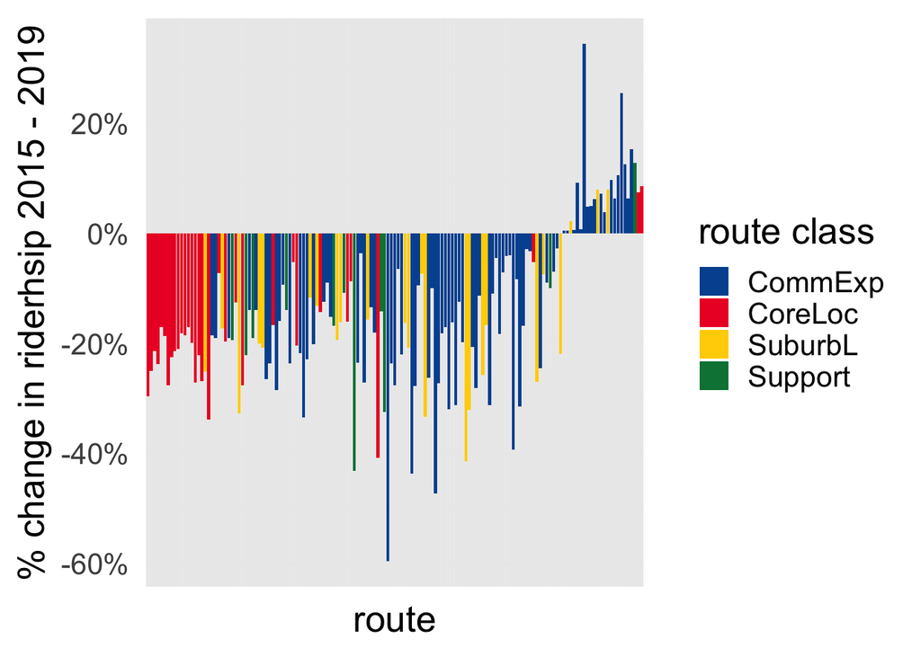

```r
p <- ggplot(dat, aes(x = factor(Route, levels = dat[order(ridesDiff), Route], order = T), y = ridesPct, fill = rte_class))
p + geom_bar(stat = 'identity') +
  theme_minimal(base_size = 20) +
  scale_fill_manual(values = MT_palette, name = 'route class') +
  scale_x_discrete(labels = NULL, name = 'route') +
  scale_y_continuous(name = '% change in riderhsip 2015 - 2019',
                     labels = scales::percent)
```

#### Distribution of log rate response (slide 9 fig):

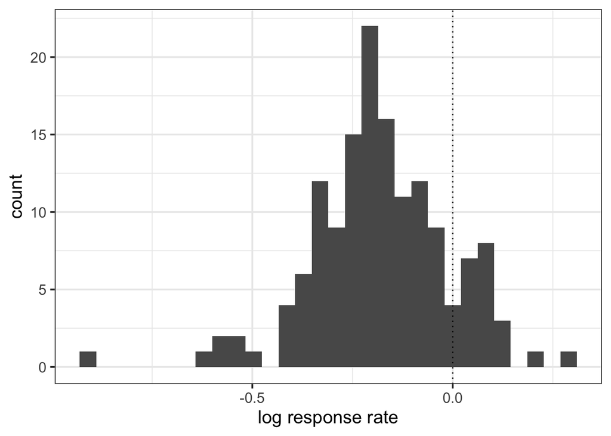

```r
ggplot(dat, aes(x = ridesRate)) + geom_histogram() +
  theme_bw(base_size = 15) +
  scale_x_continuous(name = 'log response rate') +
  geom_vline(xintercept = 0, lty = 3)
```

#### A faceted view of response by category

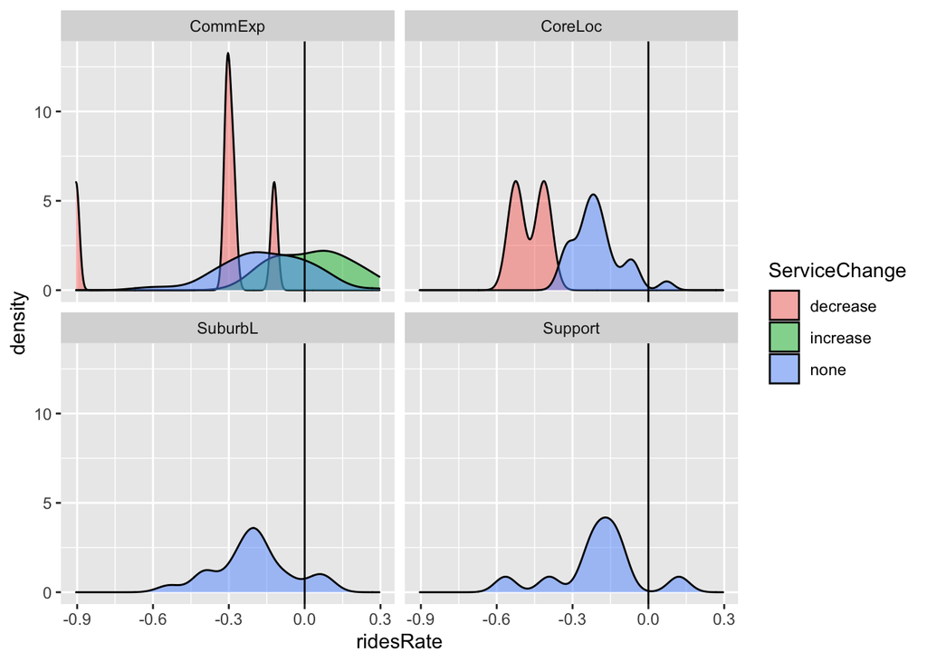

```r
ggplot(dat, aes(x = ridesRate, fill = ServiceChange)) +
  geom_density(alpha = 0.5) +
  geom_vline(xintercept = 0) +
  facet_wrap(~rte_class)
```

# Constructing the probabilistic model

### Configuring `rethinking`

The [`rethinking` package](https://github.com/rmcelreath/rethinking) is a companion to [*Statistical Rethinking: A Bayesian Course with Examples in R and STAN*](https://www.routledge.com/Statistical-Rethinking-A-Bayesian-Course-with-Examples-in-R-and-STAN/McElreath/p/book/9780367139919). The book and package build intuition from the basics of probability distributions and likelihoods, in (for me) a very effective way.

`rethinking` is most powerfully used as a translator for the `rstan` package, which is the `R` wrapper for the [Stan platform](https://mc-stan.org/).

Installation of Stan and `rstan` requires operating system-specific directions, please see [here](https://mc-stan.org/users/interfaces/rstan.html).

```r
library(rethinking)
```

```r
options(mc.cores = parallel::detectCores())
rstan_options(auto_write = TRUE)
```

The data input into `rstan` must be a list. Factors should be translated as their integer equivalents, so e.g. here the route class is `1:4` with the levels specified to match the original data.

```r
tomod <- as.list(dat[,
                        .(route = as.integer(factor(Route)),
                          cls = as.integer(factor(rte_class, levels = c('CoreLoc', 'CommExp', 'SuburbL', 'Support'))),
                          hrs_chg = HrsDiff / SumOfInSrvHrs_2015,
                          y = ridesRate)])
```

## a “null model”: single distribution of change

In this model, there is no information about how routes might be similar to each other, or whether the amount of service has changed. All observed route changes are drawn from a single distribution, with a prior probability close to zero (no change).

```r
m0 <- rethinking::map2stan(
  alist(
    y ~ dnorm(muhat, sigma), # change drawn from normal with mean, var
    muhat ~ dnorm(0, 1), # mean prior
    sigma ~ dcauchy(0, 1) # variance prior (half-cauchy to be positive)
  ),
  data = tomod, chains = 1, debug = T, control = list(max_treedepth = 15)
  )
```

[output not shown]

[output cut: 91 more lines]

[output not shown]

This gives you a feel for how the model is compiled, and then evaluated by the number of chains specified (I use just one here for demonstration). For those interested in exploring more with `stan`, note that the `rethinking::map2stan` function includes a human-readable stan model object.

In the output, the descriptors of the coefficients reflect the shape of the overall distribution (mean and variance):

```r
rethinking::precis(m0)
```

```
##             mean         sd       5.5%      94.5%     n_eff     Rhat4
## muhat -0.1792487 0.01479758 -0.2020576 -0.1571551 1021.8341 0.9994366
## sigma  0.1734796 0.01050494  0.1578728  0.1920464  928.1512 0.9990532
```

## the developed model: hierarchical

Skipping over the trial-and-fit in model development (the fun part for the statistician), a relatively simple implementation of the problem is to nest the intercept and service level coefficient in the route type classification, and then have those drawn from a common “parent” distribution.

*This model may take some time to run* if you want the full experience you can use `chains = 4, cores = 3` in the function call.

```r
m4 <- map2stan(
  alist(
    y ~ dnorm(muhat, sigma),              # same probabilistic draw as m0
    muhat <- a_C[cls] + b_H[cls]*hrs_chg, # linear predictor
    a_C[cls] ~ dnorm(A, sigma_class),     # intercept nested
    b_H[cls] ~ dnorm(B_H, sigma_hours),   # slope nested
    c(A, B_H) ~ dnorm(0, 2),              # parent distribution priors
    c(sigma, sigma_class, sigma_hours) ~ dcauchy(0, 1) # variance priors
  ),
  data = tomod, chains = 1, debug = F,
  control = list(max_treedepth = 15, adapt_delta = 0.98)
)
```

[output not shown]

```r
precis(m4) # parent parameter coefficients
```

```
##                    mean         sd        5.5%      94.5%    n_eff     Rhat4
## A           -0.18328507 0.03902773 -0.23564394 -0.1308920 491.6591 1.0005503
## B_H          0.44195806 0.16980066  0.18257392  0.6788432 429.8290 0.9994188
## sigma        0.15057719 0.00889122  0.13713958  0.1656176 729.6504 0.9999033
## sigma_class  0.05931751 0.05440424  0.01283293  0.1605875 360.3911 1.0002751
## sigma_hours  0.22559431 0.21716875  0.02731153  0.6189212 251.5957 1.0022900
```

```r
precis(m4, depth = 2) # hierarchical coefficients
```

```
##                    mean         sd        5.5%      94.5%    n_eff     Rhat4
## a_C[1]      -0.20283534 0.02403027 -0.24165730 -0.1671360 698.0761 1.0002464
## a_C[2]      -0.15406450 0.01752176 -0.18221960 -0.1265423 559.1538 1.0023882
## a_C[3]      -0.19261055 0.02723097 -0.23589152 -0.1492416 501.9461 0.9990016
## a_C[4]      -0.17998507 0.03668489 -0.23340723 -0.1174617 358.0452 1.0020935
## b_H[1]       0.53596976 0.12915080  0.35274683  0.7601354 418.6922 0.9996834
## b_H[2]       0.42219893 0.06886302  0.31130789  0.5288330 601.8697 1.0033173
## b_H[3]       0.34987822 0.17915315  0.01772729  0.5928551 566.2567 0.9997577
## b_H[4]       0.51564242 0.21277492  0.20041965  0.8816943 273.3703 0.9991375
## A           -0.18328507 0.03902773 -0.23564394 -0.1308920 491.6591 1.0005503
## B_H          0.44195806 0.16980066  0.18257392  0.6788432 429.8290 0.9994188
## sigma        0.15057719 0.00889122  0.13713958  0.1656176 729.6504 0.9999033
## sigma_class  0.05931751 0.05440424  0.01283293  0.1605875 360.3911 1.0002751
## sigma_hours  0.22559431 0.21716875  0.02731153  0.6189212 251.5957 1.0022900
```

### visualizing, output, scenarios

The wonderful thing about a hierarchical Bayesian model is that once it has been fit, interpretation and extension are very natural to consider, and implement using draws from the model probabilities themselves. Thus rather than visualizing or focusing on parameter estimates, we can integrate back to the outcomes of interest (in this case, the ridership % change) and examine the impact of those predictors on the overall outcome.

For each exploration, a predictor matrix is needed to be the new input into the model. For instance, at 0% change in hours, what is the distribution of probability of ridership change?

```r
## at 0% hours change, what can we expect?
d.pred0 <- as.list(expand.grid(cls = c(1, 2, 3, 4), hrs_chg = 0))
predout0 <- rethinking::link(m4, data = d.pred0) #draws from the model with the input grid indicated
```

```
## [ 100 / 1000 ]
[ 200 / 1000 ]
[ 300 / 1000 ]
[ 400 / 1000 ]
[ 500 / 1000 ]
[ 600 / 1000 ]
[ 700 / 1000 ]
[ 800 / 1000 ]
[ 900 / 1000 ]
[ 1000 / 1000 ]
```

```r
head(predout0) # matrix output
```

```
##            [,1]       [,2]       [,3]       [,4]
## [1,] -0.1897263 -0.1303720 -0.1838511 -0.1887097
## [2,] -0.1879535 -0.1857578 -0.1895454 -0.2016594
## [3,] -0.2267669 -0.1309048 -0.1852267 -0.1457718
## [4,] -0.1826233 -0.1670056 -0.2227479 -0.1834766
## [5,] -0.1804071 -0.1410083 -0.1732208 -0.1878406
## [6,] -0.1792366 -0.1400847 -0.1867381 -0.1186639
```

Then the process to handle the output samples is:

1. make `data.table`
2. `melt`
3. plot

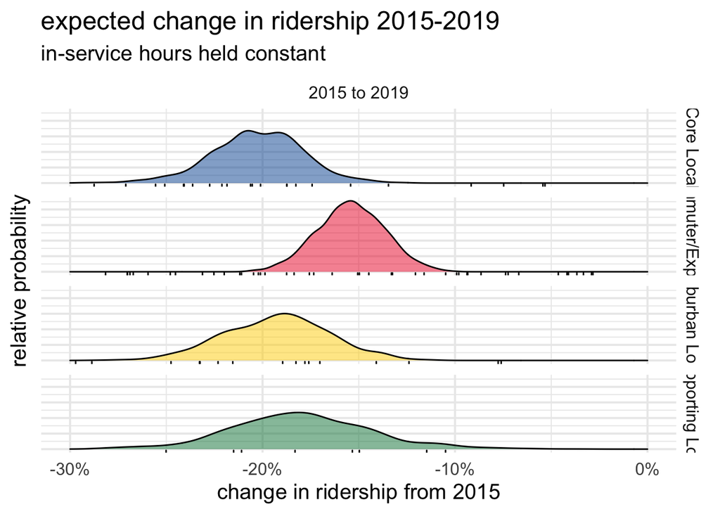

```r
tomelt <- as.data.table(predout0)
setnames(tomelt, c('Core Local', 'Commuter/Express', 'Suburban Local', 'Supporting Local'))
toplot <- melt(tomelt,variable.name = 'routeType', value.name = 'intercept')
rugplot <- data.table(routeType = factor(tomod$cls, labels = c('Core Local', 'Commuter/Express', 'Suburban Local', 'Supporting Local')),
                      intercept = tomod$y)

ggplot(toplot, aes(x = intercept, fill = routeType)) +
  theme_minimal(base_size = 15) +
  geom_density(alpha = 0.5) +
  geom_rug(data = rugplot, sides = 'b') +
  scale_y_continuous(name = 'relative probability', labels = NULL) +
  scale_x_continuous(labels = scales::percent, limits = c(-0.3, 0), name = 'change in ridership from 2015') +
  scale_fill_manual(values = MT_palette, name = '') +
  facet_grid(routeType~'2015 to 2019') +
  theme(legend.position = 'none') +
  ggtitle('expected change in ridership 2015-2019', 'in-service hours held constant')
```

Finally, the impact on changing hours of service by route class can be visualized along a sequential predictor from -50% to 50% change (halving of service or adding 50% to existing service in 2015):

```r
d.pred <- as.list(expand.grid(cls = c(1, 2, 3, 4), hrs_chg = seq(-0.5, 0.5, by = 0.01)))
predout4 <- link(m4, data = d.pred)
```

```
## [ 100 / 1000 ]
[ 200 / 1000 ]
[ 300 / 1000 ]
[ 400 / 1000 ]
[ 500 / 1000 ]
[ 600 / 1000 ]
[ 700 / 1000 ]
[ 800 / 1000 ]
[ 900 / 1000 ]
[ 1000 / 1000 ]
```

```r
dim(predout4) # 1000 draws, 4 classes, 100 modeled hours changes
```

```
## [1] 1000  404
```

At this point the output matrix requires some reduction to summary statistics, while keeping dimensions straight. The nice thing is the flexibility to use any quantile or probability threshhold that you and your business units might find appropriate - no restrictive 5% thinking necessary.

Here I use the 93% credible interval.

```r
predframe4 <- data.table(expand.grid(cls = c(1, 2, 3, 4), hrs_chg = seq(-0.5, 0.5, by = 0.01))) # identifying dataframe

predframe4[, modRate := apply(predout4, 2, mean)]
predframe4[, loRate := apply(predout4, 2, PI, prob = 0.93)[1,]]
predframe4[, hiRate := apply(predout4, 2, PI, prob = 0.93)[2,]]

predframe4
```

```
##      cls hrs_chg     modRate      loRate     hiRate
##   1:   1   -0.50 -0.47082022 -0.59780614 -0.3640490
##   2:   2   -0.50 -0.36516397 -0.43258789 -0.3001309
##   3:   3   -0.50 -0.36754966 -0.51486117 -0.1707291
##   4:   4   -0.50 -0.43780628 -0.66530383 -0.2563976
##   5:   1   -0.49 -0.46546052 -0.59061056 -0.3600889
##  ---
## 400:   4    0.49  0.07267971 -0.12407003  0.3090257
## 401:   1    0.50  0.06514954 -0.04731019  0.2025055
## 402:   2    0.50  0.05703496 -0.01575672  0.1271468
## 403:   3    0.50 -0.01767144 -0.20293891  0.1330794
## 404:   4    0.50  0.07783614 -0.12139856  0.3189729
```

Finally the “interactions” plot where the slopes are varying by route class can be nicely related back to the overall change in route ridership.

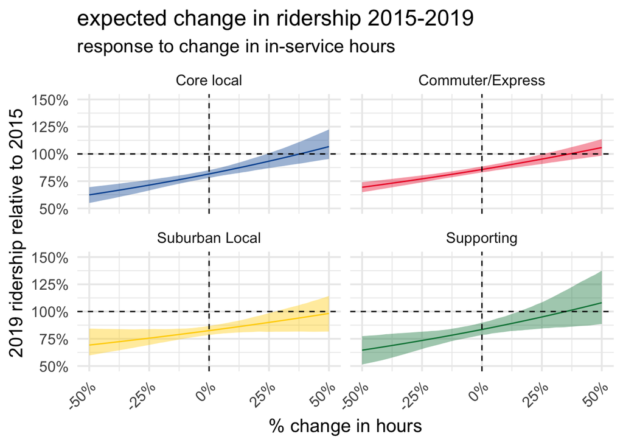

```r
ggplot(predframe4, aes(x = hrs_chg, y = exp(modRate), fill = factor(cls))) +
  theme_minimal(base_size = 15) +
  geom_ribbon(aes(ymin = exp(loRate), ymax = exp(hiRate)), alpha = 0.4) +
  geom_path(aes(col = factor(cls))) +
  scale_y_continuous(labels = scales::percent_format(accuracy = 1L), name = '2019 ridership relative to 2015', limits = c(0.5, 1.5)) +
  scale_x_continuous(labels = scales::percent, name = '% change in hours') +
  scale_fill_manual(values = alpha(MT_palette), name = '', labels = c('Core local', 'Commuter/Express', 'Suburban Local', 'Supporting')) +
  scale_color_manual(values = MT_palette, name = '', labels = c('Core local', 'Commuter/Express', 'Suburban Local', 'Supporting')) +
  facet_wrap(~factor(cls, labels = c('Core local', 'Commuter/Express', 'Suburban Local', 'Supporting'))) +
  geom_hline(yintercept = 1, lty = 2) +
  geom_vline(xintercept = 0, lty = 2) +
  theme(axis.text.x = element_text(angle = 45, hjust = 1), legend.position = 'none') +
  ggtitle('expected change in ridership 2015-2019', subtitle = 'response to change in in-service hours')
```